# R 문법 연습

- 문법 참고 사이트 : https://moon9342.github.io/R-lecture-R-environment

## R 개요

```r
# 변수 선언 및 사칙연산
myVar <- 100
result <- myVar + 200
print (result)
```

```
## [1] 300
```

```r
var1 = 3.141592
result = var1 * 2

cat("계산된 결과값은 : ", result)
```

```
## 계산된 결과값은 :  6.283184
```

```r
cat("계산된 결과값은 : ", result, "\n", file="./output.txt", append=TRUE)
# rm(list = ls())
cat("\014")
```

## R Operator

### 몫, 나머지 연산자

- 몫은 `%/%`를 사용해야하고, 나머지는 `%%`를 사용해야한다.

```r
var1 <- 1000
var2 <- 3

result <- var1 / var2
print(result)
```

```
## [1] 333.3333
```

```r
#options(digits = 5)
#result
sprintf("%0.7f", var1 / var2)
```

```
## [1] "333.3333333"
```

```r
result <- var1 %/% var2
print(result)
```

```
## [1] 333
```

```r
result <- var1 %% var2
print(result)
```

```
## [1] 1
```

### 비교연산자

```r
var1 <- 100
var2 <- 200
var1 == var2
```

```
## [1] FALSE
```

```r
print(var1 == var2)
```

```
## [1] FALSE
```

```r
print(var1 != var2)
```

```
## [1] TRUE
```

```r
print(var1 > var2)
```

```
## [1] FALSE
```

```r
print(var1 >= var2)
```

```
## [1] FALSE
```

```r
print(!(var1 <= var2))
```

```
## [1] FALSE
```

### 할당연산자

- `<-`, `->`

```r
var1 = 100
print(var1)
```

```
## [1] 100
```

```r
var2 <- 200
print(var2)
```

```
## [1] 200
```

```r
300 -> var3
print(var3)
```

```
## [1] 300
```

### 논리연산자

- `&` : 기본적으로는 논리적 and 연산. 단, 조건에 있는 값이 vector이면, 모든 조건에 대해 1대1로 연산을 수행한 후 결과를 vector로 반환
- `&&` : 기본적으로는 논리적 and 연산. 단, 조건에 있는 값이 vector이면, 첫번째 조건에 대한 연산을 수행한뒤 결과를 scalar로 반환

```r
TRUE & FALSE
```

```
## [1] FALSE
```

```r
TRUE && FALSE
```

```
## [1] FALSE
```

```r
TRUE |  FALSE
```

```
## [1] TRUE
```

```r
TRUE || FALSE
```

```
## [1] TRUE
```

```r
c(TRUE, FALSE) & c(TRUE, TRUE)
```

```
## [1]  TRUE FALSE
```

```r
c(TRUE, FALSE) && c(TRUE, TRUE)
```

```
## [1] TRUE
```

```r
c(TRUE, FALSE) & c(TRUE, TRUE, FALSE) # Error
```

```
## [1]  TRUE FALSE FALSE
```

```r
!c(TRUE, FALSE, TRUE)
```

```
## [1] FALSE  TRUE FALSE
```

### 기본적으로 제공해주는 수학함수, 값 리스트

```r
abs(-3)
```

```
## [1] 3
```

```r
sqrt(16)
```

```
## [1] 4
```

```r
pi
```

```
## [1] 3.141593
```

```r
sign(-3)
```

```
## [1] -1
```

```r
round(2.345, digits = 2)
```

```
## [1] 2.35
```

```r
ceiling(2.3)
```

```
## [1] 3
```

```r
floor(2.7)
```

```
## [1] 2
```

```r
exp(10)
```

```
## [1] 22026.47
```

```r
log(10)
```

```
## [1] 2.302585
```

```r
log10(10)
```

```
## [1] 1
```

```r
logb(10, base=3)
```

```
## [1] 2.095903
```

```r
factorial(4)
```

```
## [1] 24
```

```r
choose(4, 2)
```

```
## [1] 6
```

```r
prod(1:4)
```

```
## [1] 24
```

```r
sign(0.5)
```

```
## [1] 1
```

```r
cos(0.5)
```

```
## [1] 0.8775826
```

```r
tan(0.5)
```

```
## [1] 0.5463025
```

## R Data Type

### 기본 데이터 타입

- Numeric : 숫자로 되어있으며 정수형과 실수형을 의미한다. `L` 기호를 이용하면 정수형, 그렇지 않으면 실수형으로 간주한다
- Character : 하나의 문자 혹은 문자열로 되어있으며 `""` 혹은 `''`을 사용한다.
- Logical : 참과 거짓의 논리값으로 `TRUE`(`T`) 혹은 `FALSE`(`F`)로 표현된다.
- Complex : 실수와 허수로 이루어진 복소수형태로 표현한다.

### 특수 데이터 타입

- `NULL` : 그 자체가 객체이며, 존재하지 않는 객체를 지정할 때 사용된다.
- `NA` : Not Available의 약자로 결측치(missing value)를 의미한다.
- `NaN` : Not avaiable Number의 약자로 수학적으로 연산이 불가능한 수를 의미한다
- `Inf` : Infinite의 약자로 양의 무한대를 의미한다.
- `-Inf` : 음의 무한대

### 데이터 타입 관련 함수 (`mode()`, `is()`)

- `mode()` : 문자열의 형태로 리턴
- `is.Type()` : Logical Type으로 리턴
  - 지원 메서드 리스트

  ```
  is.numeric()
  is.integer()
  is.double()
  is.logical()
  is.complex()
  is.null()
  is.na()
  is.finite()
  is.infinite()
  ```

```r
var1 = "Hello"
mode(var1)
```

```
## [1] "character"
```

```r
is.numeric(var1)
```

```
## [1] FALSE
```

```r
is.character(var1)
```

```
## [1] TRUE
```

### Data Type의 우선순위

- vector는 하나의 Data Type만을 가질수 있다.
- 여러개의 타입을 하나의 vector에 넣으면 다음과 같은 순서로 Type Casting이 일어나게 된다.
- character > complex > numeric > logical

```r
var1 <- c(100, TRUE, 3.1415)
var2 <- c(100, TRUE, 3.1415, "Hello")
var3 <- c(100, FALSE, 3-4i)
var4 <- c(100, FALSE, 3-4i, "안녕!!")

var1
```

```
## [1] 100.0000   1.0000   3.1415
```

```r
var2
```

```
## [1] "100"    "TRUE"   "3.1415" "Hello"
```

```r
var3
```

```
## [1] 100+0i   0+0i   3-4i
```

```r
var4
```

```
## [1] "100"    "FALSE"  "3-4i"   "안녕!!"
```

### Type Casing 함수 `as()`

```r
var1 <- 3.1415
var2 <- 0
var3 <- "3.141592"
var4 <- "Hello"
as.character(var1)
```

```
## [1] "3.1415"
```

```r
as.double(var1)
```

```
## [1] 3.1415
```

```r
as.integer(var1)
```

```
## [1] 3
```

```r
as.numeric(var1)
```

```
## [1] 3.1415
```

```r
as.logical(var1)
```

```
## [1] TRUE
```

```r
as.logical(var2)
```

```
## [1] FALSE
```

```r
as.double(var3)
```

```
## [1] 3.141592
```

```r
as.integer(var3)
```

```
## [1] 3
```

```r
as.double(var4)
```

```
## [1] NA
```

## R 패키지와 함수

- R은 `Base system`과 `Other package`로 구별할수 있다.
  - `Base system`에는 `Base package`, `Recommended package`로 구분된다.
- `Base package` 는 설치가 필요없고 사용하기 위해서 불러오기(`library()`)를 할 필요가 없다.
- `Recommended package`는 설치는 필요없지만, 불러오기(`library()`)를 해야지 사용가능하다
- `Other package`는 설치, 불러오기 둘다 해야지만 사용 가능하다.

### package 설치하기

- `install.packages('패키지명')` : 패키지 설치하기
- `installed.packages()` : 설치된 패키지 확인하기
- `.libPaths()` : library 설치경로 확인
- `.libPaths(pathname)` : 설치경로 변경

### package 사용

- `library(packagename)`, `require(packagename)`

### package 제거

- `remove.packages(packagename)`

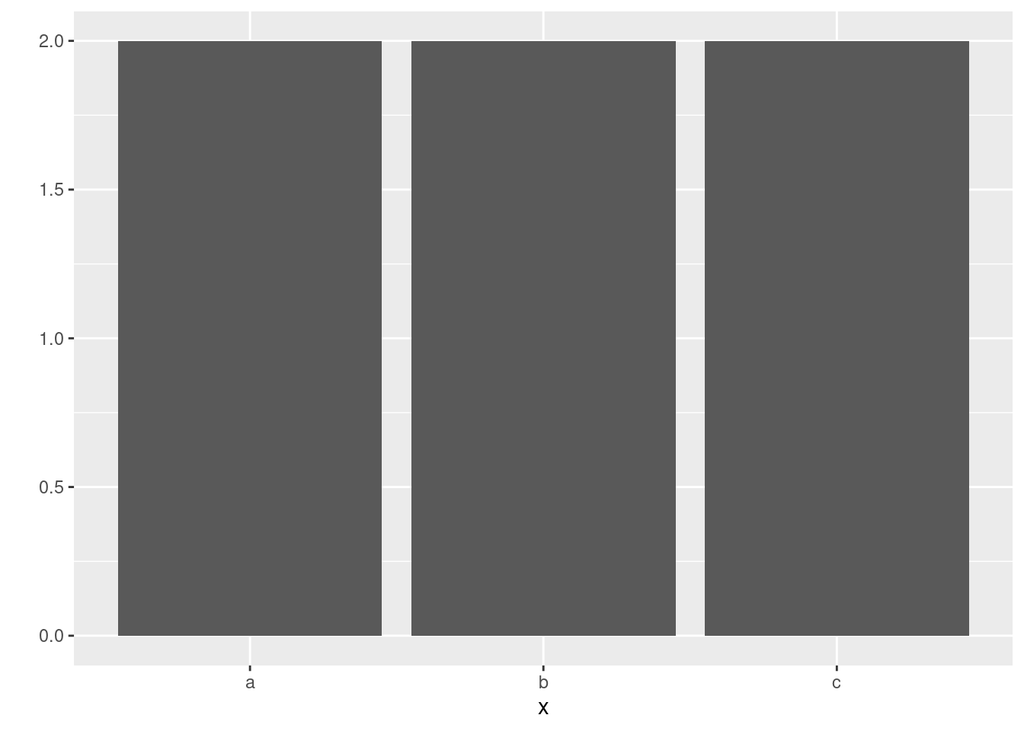

```r
install.packages("ggplot2")
library(ggplot2)
x <- c("a", "b", "c", "a", "b", "c")
qplot(x)
```

```r
remove.packages("ggplot2")
```

```
## * Removing package(s) from project library ...
## Removing package 'ggplot2' ... Done!
```

```r
.libPaths()
```

```
## [1] "/home/syslab/workspace/r/learning_r/renv/library/R-3.6/x86_64-pc-linux-gnu"
## [2] "/tmp/Rtmpw9wySv/renv-system-library"
```

### 도움 함수들

- `help()` : display function’s manual
- `args()` : display arguments of function
- `example()` : display examples of fuction

```r
help(mean)
args(max)
```

```
## function (..., na.rm = FALSE)
## NULL
```

```r
example(mean)
```

```
##
## mean> x <- c(0:10, 50)
##
## mean> xm <- mean(x)
##
## mean> c(xm, mean(x, trim = 0.10))
## [1] 8.75 5.50
```

```
##
## qplot> # Use data from data.frame
## qplot> qplot(mpg, wt, data = mtcars)
```

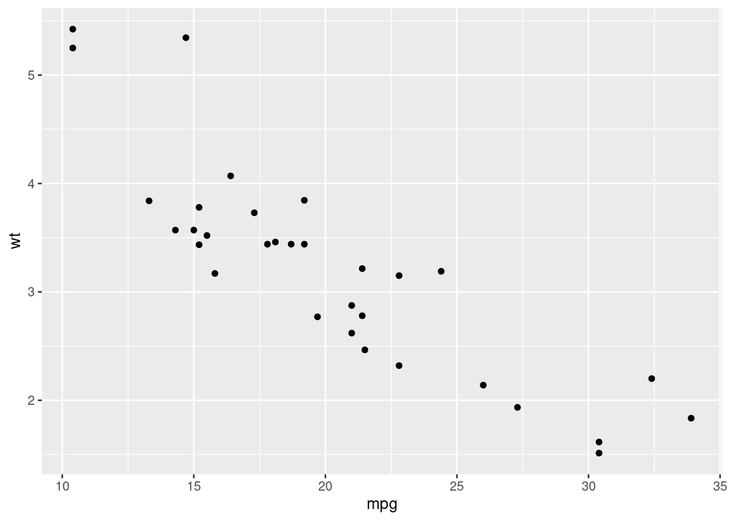

```
##
## qplot> qplot(mpg, wt, data = mtcars, colour = cyl)
```

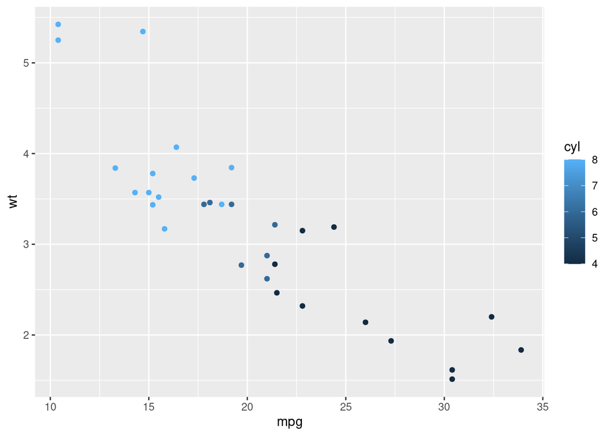

```
##
## qplot> qplot(mpg, wt, data = mtcars, size = cyl)
```

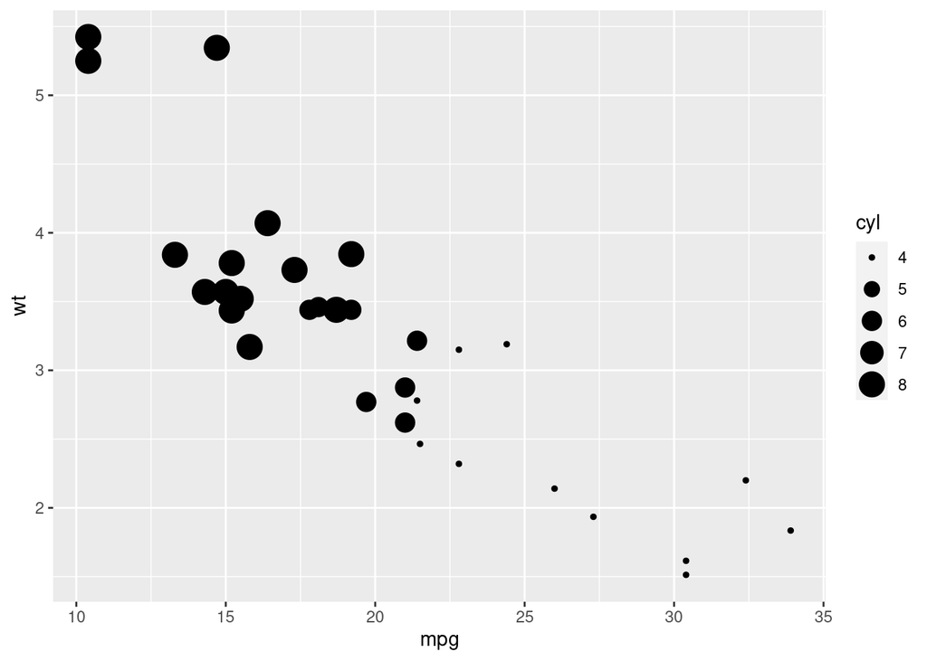

```
##
## qplot> qplot(mpg, wt, data = mtcars, facets = vs ~ am)
```

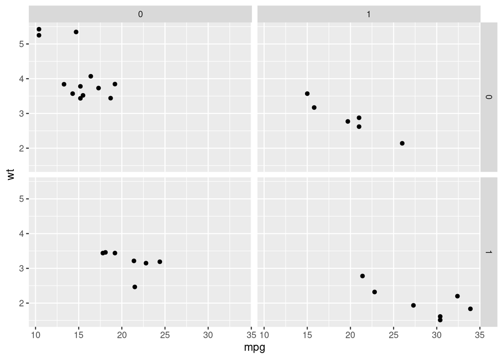

[output not shown]

```r
example(qplot)
```

### Workspace

- `getwd()` : return current workspace directory characters.
- `setwd(dirname)` : change working directory to `dirname`

## Chatper 5. vector

### Major Data Structure

- `Vector` : one-dimension array
- `Matrix` : two-dimension array
- `Array` : multiple-dimension array
- `List` : multiple wrapper data structure
- `Data Frame` : two-dimension table

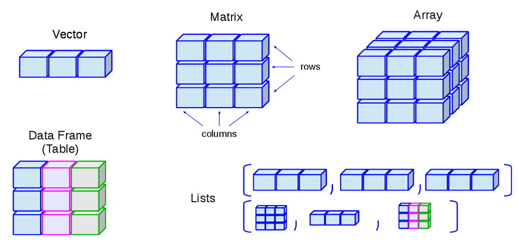

### The properties of `Vector`

- one-dimension
- Single Data Type (All elements will be cast to the same type.)
- Each elements are accessed using `variable_name[index]`. `index` is always started from 1. (1-Index)
- We call a vector, which has only one element, `scalar`. It means `scalar` is also `Vector`.

### How to create `Vector`

#### `c()`

- `c()` is the abbreviation for “combine”.

#### `:`

- `:` can be applied to only numeric. It creates elements in increments of 1.

```r
 var1 = 1:5
 var1
```

```
## [1] 1 2 3 4 5
```

```r
 var2 = 5:0
 var2
```

```
## [1] 5 4 3 2 1 0
```

```r
 var3 = 3.3:10
 var3
```

```
## [1] 3.3 4.3 5.3 6.3 7.3 8.3 9.3
```

#### `seq()`

- `seq()` is a generic form of `:`. It has three arguments, `from`, `to`, `by`.

```r
var1 = seq(from=1, to=5, by=1)
var1
```

```
## [1] 1 2 3 4 5
```

#### `rep()`

```r
var1 = rep(1:3, times=3)
var1
```

```
## [1] 1 2 3 1 2 3 1 2 3
```

```r
var2 = rep(1:3, each=3)
var2
```

```
## [1] 1 1 1 2 2 2 3 3 3
```

### How to get the length of vector : `length()`

- `length()`

```r
var1 = seq(1, 100, 2)
length(var1)
```

```
## [1] 50
```

### How to access an element of vector

- Using Index

```r
var1 = c(67, 90, 80, 50, 100)
var1[1]
```

```
## [1] 67
```

```r
var1[length(var1)]
```

```
## [1] 100
```

```r
var1[6]
```

```
## [1] NA
```

```r
var1[-1]
```

```
## [1]  90  80  50 100
```

```r
var1[-(2:5)]
```

```
## [1] 67
```

- Using name

```r
var1 = c(10, 20, 30)
names(var1)
```

```r
names(var1) = c("Kor", "Eng", "Mat")
names(var1)
```

```
## [1] "Kor" "Eng" "Mat"
```

```r
var1
```

```
## Kor Eng Mat
##  10  20  30
```

```r
var1[1]
```

```
## Kor
##  10
```

```r
var1["Kor"]
```

```
## Kor
##  10
```

### Recycling Rule

- When we operate two vectors which of length are different, R tries to upscale the smaller.
- In this process, R has need to create new elements. So we can offer the rule of creating them.
- It called “recycling rule”.

```r
var1 = 1:3
var2 = 4:6
var1
```

```
## [1] 1 2 3
```

```r
var2
```

```
## [1] 4 5 6
```

```r
var1 * 2
```

```
## [1] 2 4 6
```

```r
var1 + 10
```

```
## [1] 11 12 13
```

```r
var2 = 1:6
var1 + var2
```

```
## [1] 2 4 6 5 7 9
```

```r
var3 = 1:5
var1 + var3
```

```
## [1] 2 4 6 5 7
```

### set operations between Vector

- `union()`
- `intersect()`
- `setdiff()`

```r
var1 = c(1, 2, 3, 4, 5)
var2 = seq(3, 7)
union(var1, var2)
```

```
## [1] 1 2 3 4 5 6 7
```

```r
intersect(var1, var2)
```

```
## [1] 3 4 5
```

```r
setdiff(var1, var2)
```

```
## [1] 1 2
```

### Comparsion of vector

- `identical()`
- `setequal()`

```r
var1 = c("HONG", "KIM", "CHOI")
var2 = c("A", "B", "C")
var3 = c("A", "B", "A", "C")
identical(var2, var3)
```

```
## [1] FALSE
```

```r
setequal(var2, var3)
```

```
## [1] TRUE
```

### How to create vector without elements

```r
var1 = vector(mode="numeric", length=10)
var1
```

```
##  [1] 0 0 0 0 0 0 0 0 0 0
```

## Chapter 6. Matrix

```r
var1 = matrix(c(1:5))
var1
```

```
##      [,1]
## [1,]    1
## [2,]    2
## [3,]    3
## [4,]    4
## [5,]    5
```

```r
var2 = matrix(c(1:10), nrow=2)
var2
```

```
##      [,1] [,2] [,3] [,4] [,5]
## [1,]    1    3    5    7    9
## [2,]    2    4    6    8   10
```

```r
var3 = matrix(c(1:13), nrow=3)
var3
```

```
##      [,1] [,2] [,3] [,4] [,5]
## [1,]    1    4    7   10   13
## [2,]    2    5    8   11    1
## [3,]    3    6    9   12    2
```

```r
var4 = matrix(c(1:10), nrow=2, byrow=T)
var4
```

```
##      [,1] [,2] [,3] [,4] [,5]
## [1,]    1    2    3    4    5
## [2,]    6    7    8    9   10
```

```r
var5 = c(1, 2, 3, 4)
var6 = c(5, 6, 7, 8)
mat1 = rbind(var5, var6)
mat1
```

```
##      [,1] [,2] [,3] [,4]
## var5    1    2    3    4
## var6    5    6    7    8
```

```r
mode(mat1)
```

```
## [1] "numeric"
```

```r
class(mat1)
```

```
## [1] "matrix"
```

### How to access elements of matrix

- `variable_name[row_idx, col_idx]`
- specific row : `variable_name[row_idx, ]`
- specific col : `variable_name[, col_idx]`

```r
var1 = matrix(1:21, nrow=3, ncol=7)
var1
```

```
##      [,1] [,2] [,3] [,4] [,5] [,6] [,7]
## [1,]    1    4    7   10   13   16   19
## [2,]    2    5    8   11   14   17   20
## [3,]    3    6    9   12   15   18   21
```

```r
var1[2, 2]
```

```
## [1] 5
```

```r
var1[2,]
```

```
## [1]  2  5  8 11 14 17 20
```

```r
var1[,3]
```

```
## [1] 7 8 9
```

```r
var1[c(1,3), c(5:7)]
```

```
##      [,1] [,2] [,3]
## [1,]   13   16   19
## [2,]   15   18   21
```

```r
length(var1)
```

```
## [1] 21
```

```r
nrow(var1)
```

```
## [1] 3
```

```r
ncol(var1)
```

```
## [1] 7
```

```r
apply(X=var1, MARGIN=1, FUN=max)
```

```
## [1] 19 20 21
```

```r
apply(X=var1, MARGIN=2, FUN=min)
```

```
## [1]  1  4  7 10 13 16 19
```

### How to operate with matrix.

```r
var1 = matrix(c(1:6), ncol=3)
var1
```

```
##      [,1] [,2] [,3]
## [1,]    1    3    5
## [2,]    2    4    6
```

```r
var2 = matrix(c(1, -1, 2, -2, 1, -1), ncol=3)
var2
```

```
##      [,1] [,2] [,3]
## [1,]    1    2    1
## [2,]   -1   -2   -1
```

```r
var1 * var2 # elementwise product
```

```
##      [,1] [,2] [,3]
## [1,]    1    6    5
## [2,]   -2   -8   -6
```

```r
t(var1)
```

```
##      [,1] [,2]
## [1,]    1    2
## [2,]    3    4
## [3,]    5    6
```

```r
var3 = matrix(c(1, -1, 2, -2, 1, -1), ncol=2)
var3
```

```
##      [,1] [,2]
## [1,]    1   -2
## [2,]   -1    1
## [3,]    2   -1
```

```r
var1 %*% var3 # matrix product
```

```
##      [,1] [,2]
## [1,]    8   -4
## [2,]   10   -6
```

```r
var1 = matrix(c(1,2,3,3,0,1,5,4,2), ncol=3)
var1
```

```
##      [,1] [,2] [,3]
## [1,]    1    3    5
## [2,]    2    0    4
## [3,]    3    1    2
```

```r
solve(var1) # matrix inversion
```

```
##             [,1]        [,2] [,3]
## [1,] -0.13333333 -0.03333333  0.4
## [2,]  0.26666667 -0.43333333  0.2
## [3,]  0.06666667  0.26666667 -0.2
```

### R array

- Array is a type of multiple array with the same type.

```r
var1 = array(c(1:24), dim=c(3, 2, 4))
var1
```

```
## , , 1
##
##      [,1] [,2]
## [1,]    1    4
## [2,]    2    5
## [3,]    3    6
##
## , , 2
##
##      [,1] [,2]
## [1,]    7   10
## [2,]    8   11
## [3,]    9   12
##
## , , 3
##
##      [,1] [,2]
## [1,]   13   16
## [2,]   14   17
## [3,]   15   18
##
## , , 4
##
##      [,1] [,2]
## [1,]   19   22
## [2,]   20   23
## [3,]   21   24
```

## R factor

- `factor` is a type for categorical data.
- The list of `factor`’s values is called `level`

### Properties of `factor`

- The arguments is generally `vector`.
- `levels` is a `vector` of `character`s.
- `ordered` is a `logical` type values. `T` means `ordered data`, `F` means `unordered data`.

```r
var1 = c("A", "O", "AB", "B", "A", "O", "A")
var1
```

```
## [1] "A"  "O"  "AB" "B"  "A"  "O"  "A"
```

```r
var1_factor = factor(var1)
var1_factor
```

```
## [1] A  O  AB B  A  O  A
## Levels: A AB B O
```

```r
nlevels(var1_factor)
```

```
## [1] 4
```

```r
levels(var1_factor)
```

```
## [1] "A"  "AB" "B"  "O"
```

```r
is.factor(var1_factor)
```

```
## [1] TRUE
```

```r
ordered(var1)
```

```
## [1] A  O  AB B  A  O  A
## Levels: A < AB < B < O
```

```r
var1_factor = factor(var1, levels = c("O", "A", "B"), ordered = T)
var1_factor
```

```
## [1] A    O    <NA> B    A    O    A
## Levels: O < A < B
```

```r
var1_factor = factor(var1, levels = c("O", "A", "B", "AB"), ordered = T)
var1_factor
```

```
## [1] A  O  AB B  A  O  A
## Levels: O < A < B < AB
```

```r
levels(var1_factor) = c("A형", "AB형", "B형", "O형")
levels(var1_factor)
```

```
## [1] "A형"  "AB형" "B형"  "O형"
```

```r
var1_factor
```

```
## [1] AB형 A형  O형  B형  AB형 A형  AB형
## Levels: A형 < AB형 < B형 < O형
```

### Practice

```r
gender = c("MAN", "WOMAN", "MAN", "MAN", "WOMAN")
gender
```

```
## [1] "MAN"   "WOMAN" "MAN"   "MAN"   "WOMAN"
```

```r
factor_gender = as.factor(gender)
factor_gender
```

```
## [1] MAN   WOMAN MAN   MAN   WOMAN
## Levels: MAN WOMAN
```

```r
table(factor_gender)
```

```
## factor_gender
##   MAN WOMAN
##     3     2
```

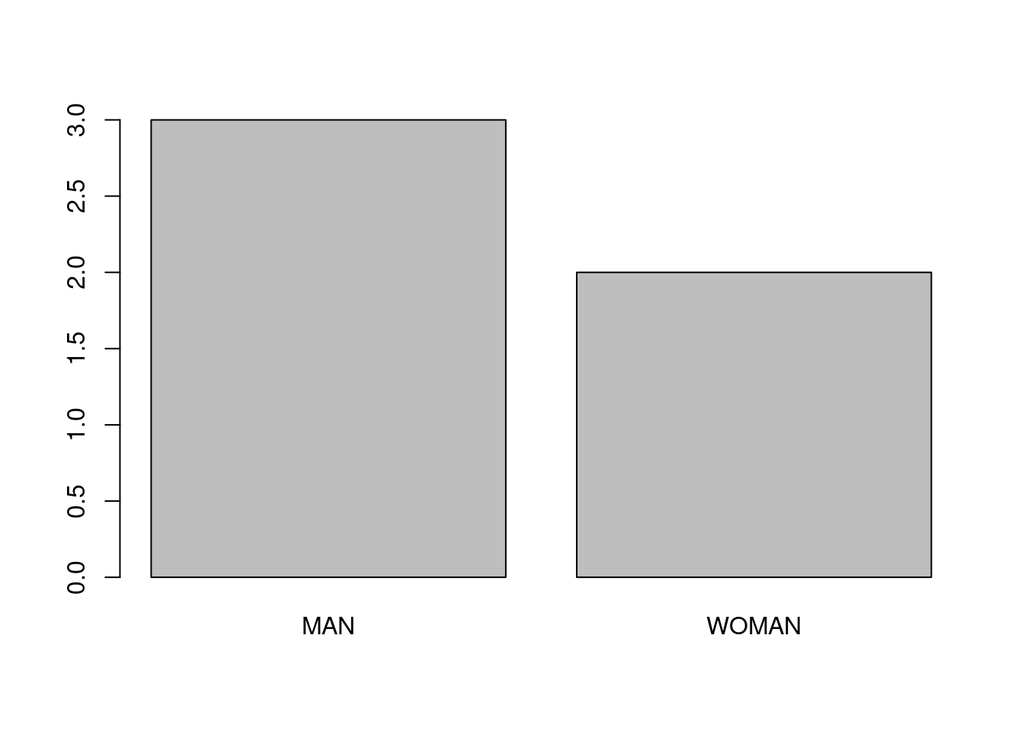

```r
plot(factor_gender)
```

## R list

```r
var_scalar = 100
var_scalar
```

```
## [1] 100
```

```r
var_vector = c(10, 20, 30)
var_vector
```

```
## [1] 10 20 30
```

```r
var_matrix = matrix(1:4, nrow = 2, ncol = 2)
var_matrix
```

```
##      [,1] [,2]
## [1,]    1    3
## [2,]    2    4
```

```r
var_array = array(1:8, dim=c(2, 2, 2))
var_array
```

```
## , , 1
##
##      [,1] [,2]
## [1,]    1    3
## [2,]    2    4
##
## , , 2
##
##      [,1] [,2]
## [1,]    5    7
## [2,]    6    8
```

```r
var_df = data.frame(id=1:3, age=c(10, 15, 20))
var_df
```

| id | age |
| --- | --- |
| 1 | 10 |
| 2 | 15 |
| 3 | 20 |

```r
var_factor = factor(c("A", "B", "C", "A", "B", "A"))
var_factor
```

```
## [1] A B C A B A
## Levels: A B C
```

```r
my_list = list(var_scalar, var_vector, var_matrix, var_array, var_df, var_factor)
my_list
```

```
## [[1]]
## [1] 100
##
## [[2]]
## [1] 10 20 30
##
## [[3]]
##      [,1] [,2]
## [1,]    1    3
## [2,]    2    4
##
## [[4]]
## , , 1
##
##      [,1] [,2]
## [1,]    1    3
## [2,]    2    4
##
## , , 2
##
##      [,1] [,2]
## [1,]    5    7
## [2,]    6    8
##
##
## [[5]]
##   id age
## 1  1  10
## 2  2  15
## 3  3  20
##
## [[6]]
## [1] A B C A B A
## Levels: A B C
```

## R dataframe

- `Data Frame` is similar to a table.
- It can store different type data per column.
- It is an composition of `list` and `vector`. Column is `list`. The data of columns are `Vector`

### Practice

```r
no = c(1, 2, 3)
name = c("HONG", "CHOI", "KIM")
pay = c(250, 150, 300)

df = data.frame(NO=no, Name=name, Pay=pay)

df
```

| NO | Name | Pay |
| --- | --- | --- |
| 1 | HONG | 250 |
| 2 | CHOI | 150 |
| 3 | KIM | 300 |

```r
mat1 = matrix(data = c(1, "HONG", 150, 2, "CHOI", 150, 3, "KIM", 300), nrow = 3, by= T)

mat1
```

```
##      [,1] [,2]   [,3]
## [1,] "1"  "HONG" "150"
## [2,] "2"  "CHOI" "150"
## [3,] "3"  "KIM"  "300"
```

```r
memp = data.frame(mat1)
memp
```

| X1 | X2 | X3 |
| --- | --- | --- |
| 1 | HONG | 150 |
| 2 | CHOI | 150 |
| 3 | KIM | 300 |

```r
df = data.frame(x=c(1: 5), y=seq(2, 10, 2), z=c("a", "b", "c", "d", "e"))
df
```

| x | y | z |
| --- | --- | --- |
| 1 | 2 | a |
| 2 | 4 | b |
| 3 | 6 | c |
| 4 | 8 | d |
| 5 | 10 | e |

```r
df$x
```

```
## [1] 1 2 3 4 5
```

### Functions of Data Frame

- `str()` is a function that displays the structure of dataframe.
- `summary()` is a function, which displays simple statistical values of the argument.
- The prototype of `apply()` is `apply(df, row or col, function)`.
  - It applies the function to each row or col.
- The prototype of `subset()` is `subset(df, condition)`.
  - It fetches another dataframe with data satisfied the condition.

```r
df = data.frame(x=c(1:5), y=seq(2,10,2), z= c("a", "b", "c", "d", "e"))
str(df)
```

```
## 'data.frame':    5 obs. of  3 variables:
##  $ x: int  1 2 3 4 5
##  $ y: num  2 4 6 8 10
##  $ z: Factor w/ 5 levels "a","b","c","d",..: 1 2 3 4 5
```

```r
df = data.frame(x = c(1:5), y= seq(2, 10, 2), z= c("a", "b", "c", "d", "e"), stringAsFactors = F)

df
```

| x | y | z | stringAsFactors |
| --- | --- | --- | --- |
| 1 | 2 | a | FALSE |
| 2 | 4 | b | FALSE |
| 3 | 6 | c | FALSE |
| 4 | 8 | d | FALSE |
| 5 | 10 | e | FALSE |

```r
str(df)
```

```
## 'data.frame':    5 obs. of  4 variables:
##  $ x              : int  1 2 3 4 5
##  $ y              : num  2 4 6 8 10
##  $ z              : Factor w/ 5 levels "a","b","c","d",..: 1 2 3 4 5
##  $ stringAsFactors: logi  FALSE FALSE FALSE FALSE FALSE
```

```r
summary(df)
```

```
##        x           y      z     stringAsFactors
##  Min.   :1   Min.   : 2   a:1   Mode :logical
##  1st Qu.:2   1st Qu.: 4   b:1   FALSE:5
##  Median :3   Median : 6   c:1
##  Mean   :3   Mean   : 6   d:1
##  3rd Qu.:4   3rd Qu.: 8   e:1
##  Max.   :5   Max.   :10
```

```r
df = data.frame(x=c(1:5), y=seq(2,10,2), z= c("a", "b", "c", "d", "e"))
apply(df[, c(1, 2)], 2, sum)
```

```
##  x  y
## 15 30
```

```r
df = data.frame(x=c(1:5), y=seq(2,10,2), z= c("a", "b", "c", "d", "e"))
sub1 <- subset(df, x >= 3)
sub1
```

|  | x | y | z |
| --- | --- | --- | --- |
| 3 | 3 | 6 | c |
| 4 | 4 | 8 | d |
| 5 | 5 | 10 | e |

```r
sub2 <- subset(df, x >=3 & y <= 8)
sub2
```

|  | x | y | z |
| --- | --- | --- | --- |
| 3 | 3 | 6 | c |
| 4 | 4 | 8 | d |

## chatper9. how to process characters.

- `stringr` is a package that contains functions of string.

```r
install.packages('stringr')
library('stringr')

myStr <- "Hongkd1051Leess1002YOU25Kim2004"
str_length(myStr)
```

```
## [1] 31
```

```r
str_locate(myStr, "Kim")
```

```
##      start end
## [1,]    25  27
```

```r
str_sub(myStr, 1, str_length(myStr) - 7)
```

```
## [1] "Hongkd1051Leess1002YOU25"
```

```r
str_to_upper(myStr)
```

```
## [1] "HONGKD1051LEESS1002YOU25KIM2004"
```

```r
str_to_lower(myStr)
```

```
## [1] "hongkd1051leess1002you25kim2004"
```

```r
myStr <- "Hongkd1051,Leess1002,You25,Kim2004"
str_replace(myStr, "Hong", "CHOI")
```

```
## [1] "CHOIkd1051,Leess1002,You25,Kim2004"
```

```r
str_c(myStr, ",Park2021")
```

```
## [1] "Hongkd1051,Leess1002,You25,Kim2004,Park2021"
```

```r
str_split(myStr, ",")
```

```
## [[1]]
## [1] "Hongkd1051" "Leess1002"  "You25"      "Kim2004"
```

```r
str1 <- c("HONG", "KIM", "LEE", "KANG")
paste(str1, collapse=",")
```

```
## [1] "HONG,KIM,LEE,KANG"
```

### Regular expression

```r
myId <- "991919-1234567"
str_extract_all(myId, "[0-9]{6}-[1234][0-9]{6}")
```

```
## [[1]]
## [1] "991919-1234567"
```

## Data I/O

### Keyboard I/O

- `scan()`, `edit()`

```r
myNum = scan()
myNum
```

```
## numeric(0)
```

```r
myStr = scan(what=character())
myStr
```

```
## character(0)
```

```r
df = data.frame();
my_df = edit(df)
```

### Local File I/O

- Read data
  - `read.table()`
  - `read.csv()`
  - `read.xlsx()`
- Write Data
  - `write.table()`
  - `cat()`
  - `capture.output()`

## Control statement

```r
var1 = 30
var2 = 40
if (var1 > var2) {
   cat(var1)
} else {
   cat(var2)
}
```

```
## 40
```

```r
ifelse(var1 > var2, var1, var2)
```

```
## [1] 40
```

```r
emp_name = "HOMG"
switch(emp_name, "HONG"=30, "KIM"=40, "CHOI"=50)

name = c("CHOI", "KANG", "LEE")
which (name == "KANG")
```

```
## [1] 2
```

```r
which (name != "KANG")
```

```
## [1] 1 3
```

```r
which (name == "SIN")
```

```
## integer(0)
```

```r
for (n in seq(1, 5)) {
   print(n)
}
```

```
## [1] 1
## [1] 2
## [1] 3
## [1] 4
## [1] 5
```

```r
idx = 1
sum = 0
while (idx <= 10) {
   sum = sum + idx
   idx = idx + 1
}

cat(sum)
```

```
## 55
```

```r
myFunc = function(k) {
   return (k + 100)
}

result = myFunc(100)
result
```

```
## [1] 200
```

## Exercise

```r
#data : 2 3 5 6 7 10
# 데이터 벡터 x를 만드세요
x = c(2, 3, 5, 6, 7, 10)
print(x)
```

```
## [1]  2  3  5  6  7 10
```

```r
# 각 데이터의 제곱으로 구성된 벡터 x2를 만드세요
x2 = x * x
print(x2)
```

```
## [1]   4   9  25  36  49 100
```

```r
# 각 데이터의 제곱의 합을 구하세요
print(sum(x * x))
```

```
## [1] 223
```

```r
# 각 데이터에서 2를 뺀 값을 구하세요
print(x - 2)
```

```
## [1] 0 1 3 4 5 8
```

```r
# 최대값과 최소값을 구하세요
print(max(x))
```

```
## [1] 10
```

```r
print(min(x))
```

```
## [1] 2
```

```r
# 5보다 큰 값들로만 구성된 데이터 벡터 x_up을 만드세요
x_up = x[x>5]
print(x_up)
```

```
## [1]  6  7 10
```

```r
# 벡터 x의 길이를 구하세요
length(x)
```

```
## [1] 6
```

```r
# UsingR 패키지를 인스톨한 후 내장되어 있는 데이터셋 primes를 이용하여,
install.packages("primes")
library("primes")
```

```r
# primes 데이터 셋을 로드하세요
# 처음 6개만 출력
head(primes, 6)
```

```
## [1]  2  3  5  7 11 13
```

```r
# 1부터 2003까지 몇개의 소수가 존재하는가?
length(primes[primes >= 1 & primes <= 2003])
```

```
## [1] 304
```

```r
# 1 부터 200까지 몇개의 소수가 존재하는가?
length(primes[primes >= 1 & primes <= 200])
```

```
## [1] 46
```

```r
# 평균은 얼마인가?
mean(primes)
```

```
## [1] 3682.913
```

```r
# 1000 이상의 소수는 몇개인가?
length(primes[primes >= 1000])
```

```
## [1] 832
```

```r
# 500 부터 1000 사이 소수만을 포함한 벡터 pp를 만드세요
pp = primes[primes >= 500 & primes <= 1000]
print(pp)
```

```
##  [1] 503 509 521 523 541 547 557 563 569 571 577 587 593 599 601 607 613 617 619
## [20] 631 641 643 647 653 659 661 673 677 683 691 701 709 719 727 733 739 743 751
## [39] 757 761 769 773 787 797 809 811 821 823 827 829 839 853 857 859 863 877 881
## [58] 883 887 907 911 919 929 937 941 947 953 967 971 977 983 991 997
```

# 벡터를 입력받아 그 원소의 값을 모두 더해서 결과를 반환하는 mysum함수를 작성하세요

```r
mySum = function (v) {
   retval = 0
   for (e in v) {
      retval = retval + e
   }
   return (retval)
}

mySum(c(1:6))
```

```
## [1] 21
```

```r
# 다음과 같은 형태의 데이터를 이용하여 다음의 문제를 해결하세요
# x =
# [ 1, 5, 9,
#   2, 6, 10,
#   3, 7, 11,
#   4, 8, 12 ]

var1 = c(1, 5, 9, 2, 6, 10, 3, 7, 11, 4, 8, 12)
# 행렬(matrix) x를 만드시오.
x = matrix(var1, ncol=3, byrow = T)
print(x)
```

```
##      [,1] [,2] [,3]
## [1,]    1    5    9
## [2,]    2    6   10
## [3,]    3    7   11
## [4,]    4    8   12
```

```r
# x의 전치행렬 xt를 만드시오.
t(x)
```

```
##      [,1] [,2] [,3] [,4]
## [1,]    1    2    3    4
## [2,]    5    6    7    8
## [3,]    9   10   11   12
```

```r
# x의 첫번째 행(row)만 뽑아낸 xr1을 만드시오
xr1 = x[1,]
print(xr1)
```

```
## [1] 1 5 9
```

```r
# x의 세번째 열(col)만 뽑아낸 xc3을 만드시오
xc3 = x[,3]
print(xc3)
```

```
## [1]  9 10 11 12
```

```r
# x에서 6,7,10,11을 원소로 가지는 부분행렬 xs를 만드시오
xs = x[2:3, 2:3]
print(xs)
```

```
##      [,1] [,2]
## [1,]    6   10
## [2,]    7   11
```

```r
# x의 두번째 열(col)의 원소가 홀수인 행(row)들만 뽑아서 부분행렬 xs2를 만드시오
xs2 = x[x[,2] %% 2 ==1,]
print(xs2)
```

```
##      [,1] [,2] [,3]
## [1,]    1    5    9
## [2,]    3    7   11
```

```r
# matrix x의 각 행(row)의 평균을 구하시오
apply(x, MARGIN=1, mean)
```

```
## [1] 5 6 7 8
```

```r
# matrix x의 각 열(col)의 평균을 구하시오
apply(x, MARGIN=2, mean)
```

```
## [1]  2.5  6.5 10.5
```

```r
# DMwR라는 패키지를 설치후, 패키지에 포함된 데이터셋인 algae를 로딩하시오.
install.packages("DMwR")
library("DMwR")
DMwR::algae
```

| season | size | speed | mxPH | mnO2 | Cl | NO3 | NH4 | oPO4 | PO4 | Chla | a1 | a2 | a3 | a4 | a5 | a6 | a7 |
| --- | --- | --- | --- | --- | --- | --- | --- | --- | --- | --- | --- | --- | --- | --- | --- | --- | --- |
| winter | small | medium | 8.000 | 9.80 | 60.800 | 6.238 | 578.000 | 105.000 | 170.000 | 50.000 | 0.0 | 0.0 | 0.0 | 0.0 | 34.2 | 8.3 | 0.0 |
| spring | small | medium | 8.350 | 8.00 | 57.750 | 1.288 | 370.000 | 428.750 | 558.750 | 1.300 | 1.4 | 7.6 | 4.8 | 1.9 | 6.7 | 0.0 | 2.1 |
| autumn | small | medium | 8.100 | 11.40 | 40.020 | 5.330 | 346.667 | 125.667 | 187.057 | 15.600 | 3.3 | 53.6 | 1.9 | 0.0 | 0.0 | 0.0 | 9.7 |
| spring | small | medium | 8.070 | 4.80 | 77.364 | 2.302 | 98.182 | 61.182 | 138.700 | 1.400 | 3.1 | 41.0 | 18.9 | 0.0 | 1.4 | 0.0 | 1.4 |
| autumn | small | medium | 8.060 | 9.00 | 55.350 | 10.416 | 233.700 | 58.222 | 97.580 | 10.500 | 9.2 | 2.9 | 7.5 | 0.0 | 7.5 | 4.1 | 1.0 |
| winter | small | high | 8.250 | 13.10 | 65.750 | 9.248 | 430.000 | 18.250 | 56.667 | 28.400 | 15.1 | 14.6 | 1.4 | 0.0 | 22.5 | 12.6 | 2.9 |
| summer | small | high | 8.150 | 10.30 | 73.250 | 1.535 | 110.000 | 61.250 | 111.750 | 3.200 | 2.4 | 1.2 | 3.2 | 3.9 | 5.8 | 6.8 | 0.0 |
| autumn | small | high | 8.050 | 10.60 | 59.067 | 4.990 | 205.667 | 44.667 | 77.434 | 6.900 | 18.2 | 1.6 | 0.0 | 0.0 | 5.5 | 8.7 | 0.0 |
| winter | small | medium | 8.700 | 3.40 | 21.950 | 0.886 | 102.750 | 36.300 | 71.000 | 5.544 | 25.4 | 5.4 | 2.5 | 0.0 | 0.0 | 0.0 | 0.0 |
| winter | small | high | 7.930 | 9.90 | 8.000 | 1.390 | 5.800 | 27.250 | 46.600 | 0.800 | 17.0 | 0.0 | 0.0 | 2.9 | 0.0 | 0.0 | 1.7 |

[output cut: 190 more lines]

```r
# algae의 속성 중 NH4 의 값들에 대해,
NH4 = DMwR::algae[,"NH4"]
# NA(결측치)가 몇개인지 구하시오
length(NH4)
```

```
## [1] 200
```

```r
sum(is.na(NH4))
```

```
## [1] 2
```

```r
# 결측치를 제거하고 평균을 구하시오.
mean(NH4[!is.na(NH4)])
```

```
## [1] 501.2958
```